# Homework 04: Data frames and data wrangling

Please read the entire chapter on data transformation from  
[R for Data Science](https://r4ds.hadley.nz/data-transform) before starting this homework.

This homework relies on the `nycflights13` package, which contains several data frames, including:

- `airlines`
- `airports`
- `flights`
- `planes`
- `weather`

Loading `nycflights13` puts these data frames on the search path.

## Setup

### Load packages (do this every time)

```r
library(tidyverse)
library(nycflights13)
```

Note - if you don’t have these installed you will need to first install.packages(‘nycflights13’)

# Question 1: Filtering

Make a plot of **air time vs distance** (air time on the y-axis, distance on the x-axis) for all flights that meet the following criteria:

- originate from LaGuardia airport (`"LGA"`)
- departed on the 16th of the month
- have a flight distance of less than 2000 miles

## Your code

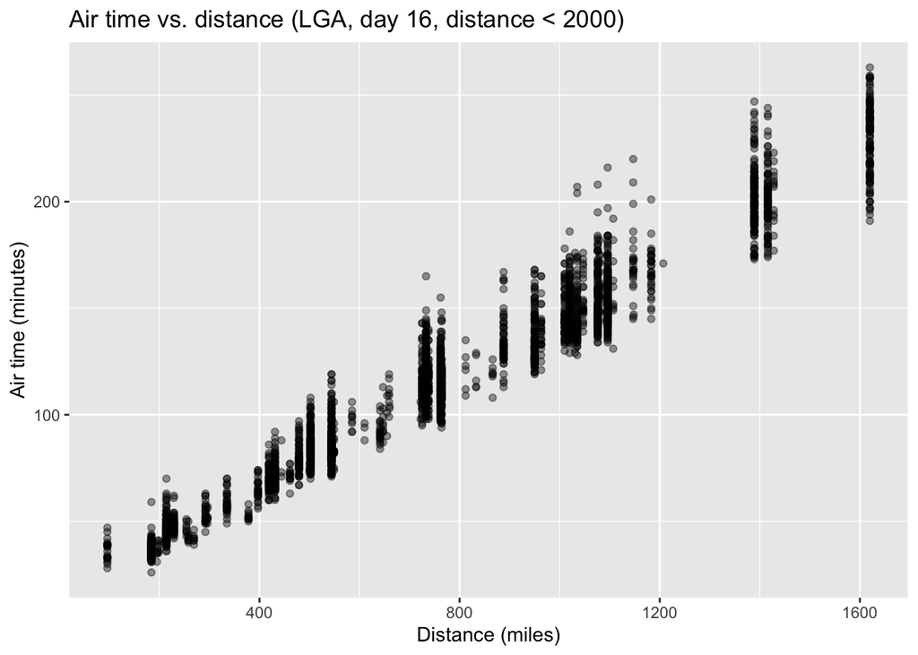

```r
library(nycflights13)
library(dplyr)
library(ggplot2)

flts_q1 <- flights %>%
  filter(
    origin == "LGA",
    day == 16,
    distance < 2000,
    !is.na(air_time),
    !is.na(distance)
  )

ggplot(flts_q1, aes(x = distance, y = air_time)) +
  geom_point(alpha = 0.4) +
  labs(
    title = "Air time vs. distance (LGA, day 16, distance < 2000)",
    x = "Distance (miles)",
    y = "Air time (minutes)"
  )
```

## Brief written response

In 2–4 sentences, describe what you observe in the plot. (For example: Is the relationship roughly linear? Are there any clear outliers?)

**Your answer here:** The plot shows a clear positive relationship: flights with longer distances generally have longer air times. The pattern is roughly linear, although there is noticeable spread, especially at mid to longer distance, likely due to routing, winds, and air traffic effects. A few points may stand out as potential outliers where air time is unusually high or low for the distance.

# Question 2: Dealing with NAs

Make a data frame of all rows of `flights` that have values for *both* `arr_time` and `dep_time` (i.e., neither value is `NA`).

## Your code

```r
flts_times <- flights %>%
  filter(!is.na(arr_time), !is.na(dep_time))

# optional: quick check
# sum(is.na(flts_times$arr_time))
# sum(is.na(flts_times$dep_time))
```

## Filtering NAs (conceptual)

`ggplot()` will automatically remove `NA` values from a plot, but it emits a warning message about it. You *could* silence warnings using chunk options, but instead:

### Brief written response

Explain (in words) how you could prevent those `NA` values from appearing in the plot in the first place.

**Your answer here:** To prevent NA values from appearing in the plot, you can remove rows with missing values prior to plotting by filtering them out. Also, using the ggplot() as mentioned above.

# Question 3: Adding columns

Create a data frame of **average flight speeds**, based on `air_time` and `distance`.

Then make either:

- a histogram, **or**
- a density plot

If you like, you may break the data out (e.g., by airline or another variable) in a way that you think makes sense.

## Your code

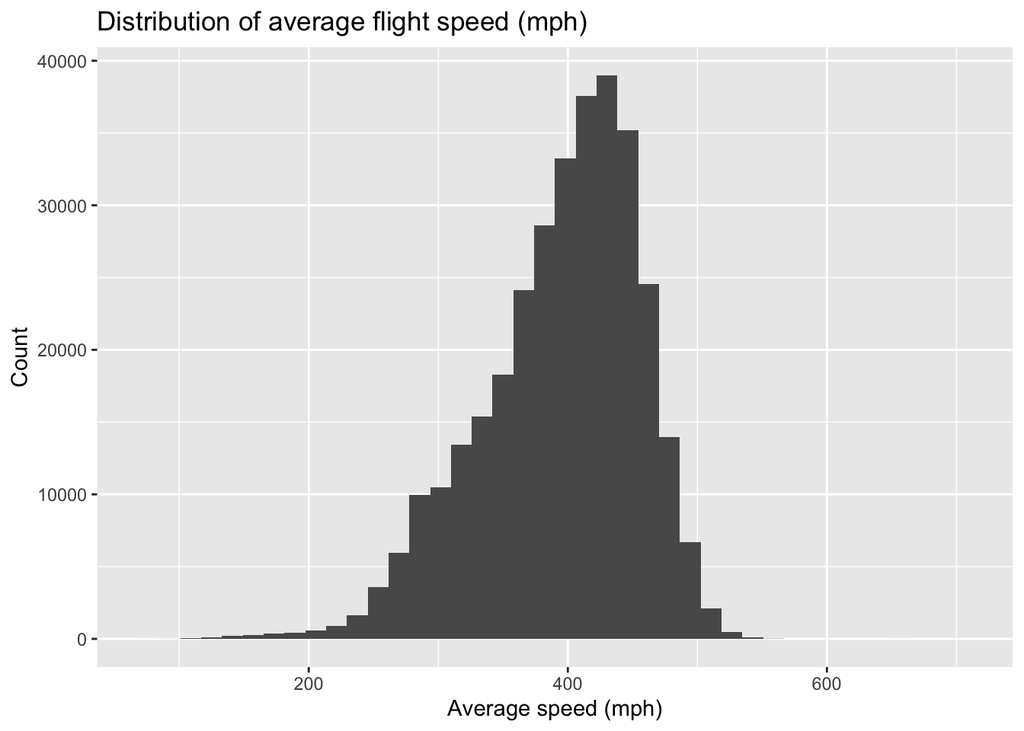

```r
speed_df <- flights %>%
  filter(!is.na(air_time), !is.na(distance), air_time > 0) %>%
  mutate(avg_speed_mph = distance / (air_time / 60))

ggplot(speed_df, aes(x = avg_speed_mph)) +
  geom_histogram(bins = 40) +
  labs(
    title = "Distribution of average flight speed (mph)",
    x = "Average speed (mph)",
    y = "Count"
  )
```

## Brief written response

Describe the main features of your speed distribution.

**Your answer here:** The speed distribution is typically unimodal with most flights clustering around a central range of average speeds. There may be a right tail with faster flights and a left tail with slower flights, reflecting differences in route length, climb/descent proportion, and conditions. Any extreme low or high speeds likely correspond to unusual air_time reporting, atypical routing, or other anomalies.

# Rendering and submission (GitHub)

Canvas contains the course GitHub link and instructions for **forking** the course repository.

In this file, your job is to:

1. Complete the homework by adding code + written responses above.
2. Render this Quarto file to **HTML or PDF**.
3. Move the rendered file(s) to the /doc folder (note that, if you render to html you will also have to move your hmk_04_data_frames_files folder)
4. Add/commit both:
   - this edited `.qmd` file
   - the rendered output file(s) (HTML or PDF)
5. Push your changes to your fork on GitHub.
6. Open a Pull Request back to the course repository.

## What to submit on Canvas

On Canvas, submit a link to your GitHub fork repository (not files).